# From Raw Data to PCM: A Complete Bird Trait Workflow

This vignette walks through a real comparative biology workflow using avian trait data and a phylogenetic tree. The same approach applies to any taxon group — mammals, fish, amphibians, plants — the functions are fully taxon-agnostic.

## Setup

```r
library(prepR4pcm)
```

# Part I: Core Workflow

The typical workflow has four steps: load your data and tree, reconcile the names, produce aligned objects, and run your analysis.

## Step 1: Load data and tree

```r
data(avonet_subset)    # AVONET morphological traits (Tobias et al. 2022)
data(tree_jetz)    # Jetz et al. (2012) phylogeny, Corvoidea + allies

cat(sprintf("Data: %d species\n", nrow(avonet_subset)))
```

```
#> Data: 919 species
```

```r
cat(sprintf("Tree: %d tips\n", ape::Ntip(tree_jetz)))
```

```
#> Tree: 657 tips
```

```r
# The data uses spaces; the tree uses underscores
head(avonet_subset$Species1, 3)
```

```
#> [1] "Acanthiza apicalis"    "Acanthiza chrysorrhoa" "Acanthiza cinerea"
```

```r
head(tree_jetz$tip.label, 3)
```

```
#> [1] "Amytornis_barbatus"  "Amytornis_merrotsyi" "Amytornis_dorotheae"
```

These formatting differences — spaces vs underscores, minor spelling variants, taxonomic synonyms — are exactly what prepR4pcm resolves.

## Step 2: Reconcile data against the tree

```r
result <- reconcile_tree(
  x = avonet_subset,
  tree = tree_jetz,
  x_species = "Species1",
  authority = NULL       # skip synonym lookup for speed
)
```

```
#> ℹ Reconciling 919 data names vs 657 tree tips
#> ℹ Matching 919 x 657 names through 2 stages...
#> ℹ Stage 1/2: Exact matching...
#> ℹ Stage 2/2: Normalised matching (0 matched so far)...
#> ✔ Matched 657/919 data names to tree tips
```

```r
print(result)
```

```
#>
#> ── Reconciliation: data vs tree ────────────────────────────────────────────────
#>   Source x: avonet_subset
#>   Source y: phylo (657 tips)
#>   Authority: none
#>   Timestamp: 2026-08-07 16:35:54
#> ℹ Match coverage: [█████████████████████░░░░░░░░░] 71% (657/919)
#>
#> ── Match summary ──
#>
#> • Exact: 0 ( 0.0%)
#> • Normalized: 657 (71.5%)
#> • Synonym: 0 ( 0.0%)
#> • Fuzzy: 0 ( 0.0%)
#> • Manual: 0 ( 0.0%)
#> ! Unresolved (x only):262 (28.5%)
#> ! Unresolved (y only):0
#> ! Flagged for review: 0
#> ℹ Use `reconcile_summary()` for details, `reconcile_mapping()` for the full table.
```

The reconciliation object records every name-matching decision. Inspect the mapping to see what happened:

```r
mapping <- reconcile_mapping(result)

# Match type breakdown
table(mapping$match_type)
```

```
#>
#> normalized unresolved
#>        657        262
```

```r
# Show normalised matches (formatting differences resolved automatically)
norm <- mapping[mapping$match_type == "normalized",
                c("name_x", "name_y", "notes")]
if (nrow(norm) > 0) head(norm, 5)
```

```
#> # A tibble: 5 × 3
#>   name_x                name_y                notes
#>   <chr>                 <chr>                 <chr>
#> 1 Acanthiza apicalis    Acanthiza_apicalis    'Acanthiza apicalis' normalised t…
#> 2 Acanthiza chrysorrhoa Acanthiza_chrysorrhoa 'Acanthiza chrysorrhoa' normalise…
#> 3 Acanthiza ewingii     Acanthiza_ewingii     'Acanthiza ewingii' normalised to…
#> 4 Acanthiza inornata    Acanthiza_inornata    'Acanthiza inornata' normalised t…
#> 5 Acanthiza iredalei    Acanthiza_iredalei    'Acanthiza iredalei' normalised t…
```

```r
# Unresolved: in data but not in tree
unresolved <- mapping[mapping$match_type == "unresolved" & mapping$in_x, ]
cat(sprintf("\nSpecies in data but not in tree: %d\n", nrow(unresolved)))
```

```
#>
#> Species in data but not in tree: 262
```

For a detailed report:

```r
reconcile_summary(result, detail = "mismatches_only")
```

[output not shown]

## Step 3: Produce aligned objects

Drop unresolved species to get a matched data frame and tree, ready for comparative analysis:

```r
aligned <- reconcile_apply(
  result,
  data = avonet_subset,
  tree = tree_jetz,
  species_col = "Species1",
  drop_unresolved = TRUE
)
```

```
#> ! Dropped 262 rows with unresolved species from data
#> ℹ Tree has 657 tips after alignment
```

```r
cat(sprintf("Aligned data: %d rows\nAligned tree: %d tips\n",
            nrow(aligned$data), ape::Ntip(aligned$tree)))
```

```
#> Aligned data: 657 rows
#> Aligned tree: 657 tips
```

## Step 4: Run a comparative analysis

With aligned data and tree, you are ready for any phylogenetic comparative method. Here are two common approaches.

### Phylogenetic generalised least squares (PGLS)

PGLS accounts for shared evolutionary history when estimating regression parameters:

```r
library(caper)

# reconcile_apply() aligns names so data$Species1 matches tree tip labels
cd <- comparative.data(aligned$tree, aligned$data,
                       names.col = "Species1", vcv = TRUE)

# PGLS: body mass ~ wing length
model_pgls <- pgls(log(Mass) ~ log(Wing.Length), data = cd)
summary(model_pgls)
```

```
#>
#> Call:
#> pgls(formula = log(Mass) ~ log(Wing.Length), data = cd)
#>
#> Residuals:
#>      Min       1Q   Median       3Q      Max
#> -0.53264 -0.04823 -0.00130  0.04332  0.50941
#>
#> Branch length transformations:
#>
#> kappa  [Fix]  : 1.000
#> lambda [Fix]  : 1.000
#> delta  [Fix]  : 1.000
#>
#> Coefficients:
#>                   Estimate Std. Error t value  Pr(>|t|)
#> (Intercept)      -5.781917   0.381775 -15.145 < 2.2e-16 ***
#> log(Wing.Length)  2.054361   0.065135  31.540 < 2.2e-16 ***
#> ---
#> Signif. codes:  0 '***' 0.001 '**' 0.01 '*' 0.05 '.' 0.1 ' ' 1
#>
#> Residual standard error: 0.09582 on 651 degrees of freedom
#> Multiple R-squared: 0.6044,  Adjusted R-squared: 0.6038
#> F-statistic: 994.8 on 1 and 651 DF,  p-value: < 2.2e-16
```

### Phylogenetic generalised linear mixed model (PGLMM)

When you need random effects beyond phylogeny or want a Bayesian framework, use a PGLMM. The MCMCglmm package fits Bayesian phylogenetic mixed models:

```r
library(MCMCglmm)

# Species column as the phylogenetic grouping factor
aligned$data$phylo <- aligned$data$Species1

# Inverse phylogenetic covariance matrix
# Replace any zero-length branches (can arise after pruning)
tree_mcmc <- aligned$tree
tree_mcmc$edge.length[tree_mcmc$edge.length < .Machine$double.eps] <- 1e-6
inv_phylo <- inverseA(tree_mcmc, nodes = "ALL", scale = FALSE)

# PGLMM: continuous response
prior <- list(R = list(V = 1, nu = 0.002),
              G = list(G1 = list(V = 1, nu = 0.002)))

model_mcmc <- MCMCglmm(
  log(Mass) ~ log(Wing.Length) + Trophic.Level,
  random = ~phylo,
  family = "gaussian",
  ginverse = list(phylo = inv_phylo$Ainv),
  data = aligned$data,
  prior = prior,
  nitt = 50000, burnin = 10000, thin = 20,
  verbose = FALSE
)
```

```r
summary(model_mcmc)
```

```
#>
#>  Iterations = 10001:49981
#>  Thinning interval  = 20
#>  Sample size  = 2000
#>
#>  DIC: -176.9922
#>
#>  G-structure:  ~phylo
#>
#>       post.mean l-95% CI u-95% CI eff.samp
#> phylo  0.001674 0.001259 0.002135     1202
#>
#>  R-structure:  ~units
#>
#>       post.mean l-95% CI u-95% CI eff.samp
#> units   0.03157  0.02631  0.03697     1756
#>
#>  Location effects: log(Mass) ~ log(Wing.Length) + Trophic.Level
#>
#>                        post.mean l-95% CI u-95% CI eff.samp  pMCMC
#> (Intercept)             -6.23936 -6.72515 -5.72234     2000 <5e-04 ***
#> log(Wing.Length)         2.15248  2.05420  2.25754     2215 <5e-04 ***
#> Trophic.LevelHerbivore   0.02528 -0.05870  0.10688     2000  0.547
#> Trophic.LevelOmnivore    0.03501 -0.03069  0.10208     2000  0.299
#> ---
#> Signif. codes:  0 '***' 0.001 '**' 0.01 '*' 0.05 '.' 0.1 ' ' 1
```

For categorical responses (e.g., migration status with multiple categories), see Mizuno et al. (2025, *J. Evol. Biol.* 38:1699–1715) for the multinomial PGLMM approach and the accompanying tutorial at https://ayumi-495.github.io/multinomial-GLMM-tutorial/.

See Hadfield (2010, *J. Stat. Softw.* 33:1–22) for MCMCglmm details, Hadfield & Nakagawa (2010, *J. Evol. Biol.* 23:494–508) for phylogenetic quantitative genetics, and Mizuno et al. (2025, *J. Evol. Biol.* 38:1699–1715) for phylogenetic multinomial mixed models.

That is the complete core workflow: **load, reconcile, apply, analyse.**

# Part II: Advanced Topics

## Reconciling two datasets

If you need to harmonise species names across two trait datasets *before* matching to a tree, use `reconcile_data()`:

```r
data(nesttrait_subset)   # Nest traits (Chia et al. 2023)

rec_data <- reconcile_data(
  x = nesttrait_subset,
  y = avonet_subset,
  x_species = "Scientific_name",
  y_species = "Species1",
  authority = NULL,
  quiet = TRUE
)
print(rec_data)
```

```
#>
#> ── Reconciliation: data vs data ────────────────────────────────────────────────
#>   Source x: nesttrait_subset
#>   Source y: avonet_subset
#>   Authority: none
#>   Timestamp: 2026-08-07 16:36:12
#> ℹ Match coverage: [██████████████████████████████] 100% (916/916)
#>
#> ── Match summary ──
#>
#> • Exact: 916 (100.0%)
#> • Normalized: 0 ( 0.0%)
#> • Synonym: 0 ( 0.0%)
#> • Fuzzy: 0 ( 0.0%)
#> • Manual: 0 ( 0.0%)
#> ! Unresolved (x only):0 ( 0.0%)
#> ! Unresolved (y only):3
#> ! Flagged for review: 0
#> ℹ Use `reconcile_summary()` for details, `reconcile_mapping()` for the full table.
```

Once reconciled, merge the two datasets into a single data frame:

```r
merged <- reconcile_merge(
  rec_data,
  data_x = nesttrait_subset,
  data_y = avonet_subset,
  species_col_x = "Scientific_name",
  species_col_y = "Species1"
)
```

```
#> ✔ Merged 916 species (inner join)
```

```r
cat(sprintf("Merged: %d rows, %d columns\n", nrow(merged), ncol(merged)))
```

```
#> Merged: 916 rows, 31 columns
```

### Multi-row species

`reconcile_merge()` assumes one row per species in each data frame. If a species appears in multiple rows (e.g. sex-specific measurements, repeated populations, or individual-level records), the merge produces all pairwise combinations for that species — the same behaviour as base `merge()`. `reconcile_merge()` warns when it detects duplicates so that you are not surprised by row expansion.

There are two sensible ways to handle multi-row data:

**Option A. Aggregate first, merge second.** If your downstream PCM expects one row per species (most PGLS and PGLMM workflows do), collapse to a species-level summary before merging:

```r
# Example: averaging individual measurements to species means
species_means <- aggregate(
  cbind(Mass, Wing.Length) ~ Species1,
  data = individual_measurements,
  FUN  = mean
)
merged <- reconcile_merge(rec_data, species_means, avonet_subset,
                          species_col_x = "Species1",
                          species_col_y = "Species1")
```

**Option B. Reconcile once, join the mapping back to the full data.** If you want to keep every row (e.g. for an individual-level PGLMM), build the reconciliation on a species-level summary and then use the mapping as a lookup table for the original, multi-row data:

```r
# Reconcile on unique species
species_level <- data.frame(
  Species1 = unique(individual_measurements$Species1)
)
rec <- reconcile_data(species_level, avonet_subset,
                      x_species = "Species1", y_species = "Species1",
                      authority = NULL, quiet = TRUE)

# Join the mapping back to the full, multi-row dataset
mapping <- reconcile_mapping(rec)
individual_measurements$species_resolved <- mapping$name_resolved[
  match(individual_measurements$Species1, mapping$name_x)
]
```

### Asymmetric datasets

A common situation in comparative biology is merging a small focal dataset against a much larger reference (e.g. a field study of 50 species against AVONET’s ~10,000). `reconcile_merge()` accepts datasets of any size, but the `how` argument matters:

```r
# Keep only species present in both: inner join
inner <- reconcile_merge(rec_data, small_data, large_data,
                         species_col_x = "species",
                         species_col_y = "Species1",
                         how = "inner")

# Keep all small_data rows; fill large_data columns with NA
# for species missing from the reference: left join
left <- reconcile_merge(rec_data, small_data, large_data,
                        species_col_x = "species",
                        species_col_y = "Species1",
                        how = "left")
```

Use `how = "inner"` when the analysis cannot tolerate `NA`s in the reference columns, and `how = "left"` when you want to retain every focal-study species (and you will handle missingness in the model). `how = "full"` is rarely what you want here — it would return the entire reference dataset padded with `NA`s for every focal trait.

## Using a taxonomy crosswalk

When your data and tree use different taxonomies (e.g., BirdLife data against a BirdTree phylogeny), a curated crosswalk can resolve names that automated synonym resolution misses.

A crosswalk is simply a table mapping names from one system to another. prepR4pcm includes the BirdLife-BirdTree crosswalk as an example:

```r
data(crosswalk_birdlife_birdtree)
table(crosswalk_birdlife_birdtree$Match.type)
```

```
#>
#>              1BL to 1BT          1BL to many BT                 Extinct
#>                    8960                     225                     143
#>          Many BL to 1BT Newly described species
#>                    1933                      24
```

Crosswalks become override tables. Overrides are applied before the matching cascade, so they can preempt exact or normalised matches. For automatic use, start with one-to-one rows only and keep split/lump rows for manual review:

```r
result_xw <- reconcile_crosswalk_supplement(
  result,
  crosswalk_birdlife_birdtree,
  from_col = "Species1",
  to_col = "Species3",
  match_type_col = "Match.type",
  one_to_one_only = TRUE,
  quiet = TRUE
)

if (result_xw$meta$crosswalk_supplement$n_applied == 0) {
  cat("No reviewed one-to-one crosswalk rows add matches in this subset.\n")
}
```

```
#> No reviewed one-to-one crosswalk rows add matches in this subset.
```

```r
# Compare: how many more matches with the crosswalk?
cat(sprintf("Without crosswalk: %d matched\n",
            sum(result$mapping$in_x & result$mapping$in_y, na.rm = TRUE)))
```

```
#> Without crosswalk: 657 matched
```

```r
cat(sprintf("With crosswalk:    %d matched\n",
            sum(result_xw$mapping$in_x & result_xw$mapping$in_y, na.rm = TRUE)))
```

```
#> With crosswalk:    657 matched
```

**When do you need a crosswalk?** Only when your data and tree follow different naming authorities *and* a curated mapping exists. For most use cases, the automatic cascade (exact → normalised → synonym) is sufficient. Treat `1BL to many BT` and `Many BL to 1BT` rows as review candidates, not automatic matches.

You can also build your own overrides manually — it is just a data frame with `name_x`, `name_y`, and optionally `user_note` columns:

```r
my_overrides <- data.frame(
  name_x    = c("Old name A", "Old name B"),
  name_y    = c("Tree name A", "Tree name B"),
  user_note = c("Reclassified in 2023", "Spelling correction")
)
result <- reconcile_tree(my_data, my_tree, overrides = my_overrides)
```

## Reconciling against multiple trees

For sensitivity analyses across phylogenies, `reconcile_to_trees()` reconciles one dataset against several trees in one call:

```r
data(tree_clements25)  # Clements 2025 tree

results <- reconcile_to_trees(
  x = avonet_subset,
  trees = list(
    jetz      = tree_jetz,
    clements  = tree_clements25
  ),
  x_species = "Species1",
  authority = NULL
)
```

```
#> ℹ Reconciling 919 data names against 2 trees
#> ℹ   [jetz] 657 tips
#> ℹ Matching 919 x 657 names through 2 stages...
#> ℹ Stage 1/2: Exact matching...
#> ℹ Stage 2/2: Normalised matching (0 matched so far)...
#> ✔   [jetz] Matched 657/919 names
#> ℹ   [clements] 854 tips
#> ℹ Matching 919 x 854 names through 2 stages...
#> ℹ Stage 1/2: Exact matching...
#> ℹ Stage 2/2: Normalised matching (0 matched so far)...
#> ✔   [clements] Matched 854/919 names
```

```r
# Compare overlap across trees
sapply(results, function(r) {
  c(matched = sum(r$mapping$in_x & r$mapping$in_y, na.rm = TRUE),
    unresolved_x = r$counts$n_unresolved_x)
})
```

```
#>              jetz clements
#> matched       657      854
#> unresolved_x  262       65
```

## Fuzzy matching for typos

Enable fuzzy matching to catch likely typos in species names:

```r
result <- reconcile_tree(
  x = my_data,
  tree = my_tree,
  fuzzy = TRUE,              # enable fuzzy matching
  fuzzy_threshold = 0.9,     # minimum similarity (0-1)
  resolve = "flag"           # flag low-confidence matches for review
)

# Check flagged matches
flagged <- reconcile_mapping(result)
flagged[flagged$match_type == "flagged", c("name_x", "name_y", "match_score")]
```

## Tree augmentation for missing species

When the tree has fewer species than the data, `reconcile_apply()` drops the unresolved species. This loses statistical power and can bias the sample. `reconcile_augment()` grafts the missing species onto the tree using genus-level placement:

```r
aug <- reconcile_augment(
  result,
  tree_jetz,
  where = "genus",                # sister to a random congener
  branch_length = "congener_median",  # median terminal branch of congeners
  seed = 42,                      # for reproducibility
  quiet = TRUE
)

cat(sprintf("Original tips: %d\nAugmented tips: %d\n",
            ape::Ntip(aug$original), ape::Ntip(aug$tree)))
```

```
#> Original tips: 657
#> Augmented tips: 793
```

```r
cat(sprintf("Added: %d | Skipped (no congener): %d\n",
            nrow(aug$augmented), nrow(aug$skipped)))
```

```
#> Added: 136 | Skipped (no congener): 126
```

```r
# Which species were added, and where?
if (nrow(aug$augmented) > 0) head(aug$augmented[, c("species", "placed_near", "branch_length")])
```

```
#> # A tibble: 6 × 3
#>   species                  placed_near             branch_length
#>   <chr>                    <chr>                           <dbl>
#> 1 Acanthiza cinerea        Acanthiza lineata                5.04
#> 2 Calamanthus cautus       Calamanthus fuliginosus          3.80
#> 3 Calamanthus montanellus  Calamanthus fuliginosus          3.80
#> 4 Calamanthus pyrrhopygius Calamanthus fuliginosus          3.80
#> 5 Gerygone citrina         Gerygone magnirostris            2.91
#> 6 Pyrrholaemus sagittatus  Pyrrholaemus brunneus           15.5
```

Use the augmented tree in downstream analyses. Pass the augmented tree to `reconcile_apply()` — the existing reconciliation object is still valid as the name-mapping key, but the new tree contains the extra tips, so `drop_unresolved = FALSE` retains the grafted species:

```r
aligned_aug <- reconcile_apply(
  result,
  data = avonet_subset,
  tree = aug$tree,        # augmented tree, not the original
  species_col = "Species1",
  drop_unresolved = FALSE  # keep augmented tips (they are now in the tree)
)
```

**Important caveat.** Genus-level placement assumes the missing species diverged similarly to its congeners, which may not hold. Always report which species were augmented (`aug$augmented`) and run sensitivity analyses comparing results with and without them.

## Exporting to files

Write aligned data, tree, and the full mapping table to disk:

```r
out_dir <- file.path(tempdir(), "prepr4pcm-export")
reconcile_export(
  result,
  data = avonet_subset,
  tree = tree_jetz,
  species_col = "Species1",
  dir = out_dir,
  prefix = "avonet_jetz"
)
# Writes: avonet_jetz_data.csv, avonet_jetz_tree.nex, avonet_jetz_mapping.csv
unlink(out_dir, recursive = TRUE)
```

## HTML reports

Generate a self-contained HTML report documenting every name-matching decision. Useful for sharing with collaborators or archiving alongside your analysis:

```r
report_file <- tempfile(fileext = ".html")
reconcile_report(result, file = report_file)
unlink(report_file)
```

[figure not shown]

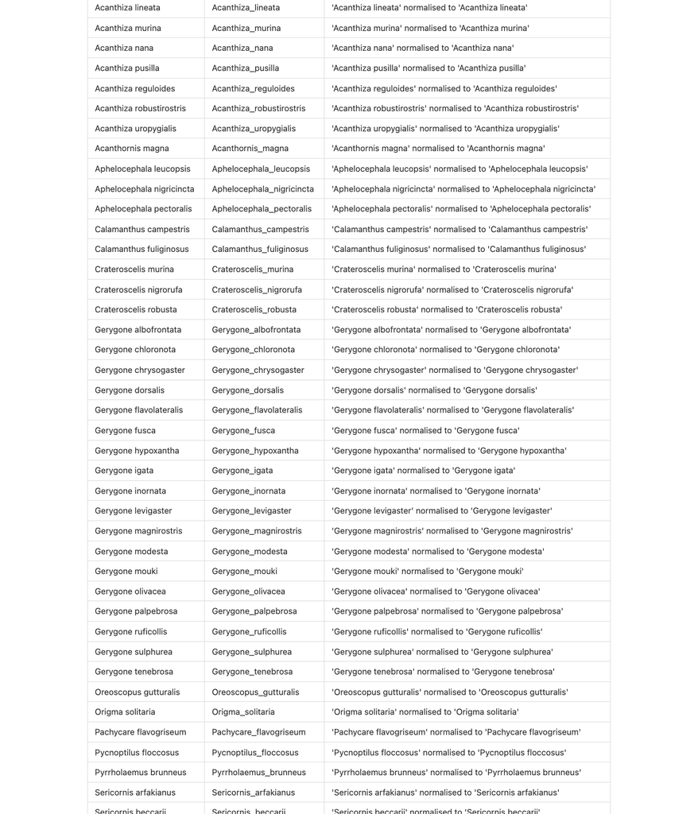

## Key points

1. **Taxon-agnostic.** This workflow works for any group — mammals, fish, amphibians, plants — as long as you have a data frame and a phylogenetic tree.
2. **Provenance.** Every name-matching decision is recorded in the `reconciliation` object. Use `reconcile_summary()` for a human-readable report or `reconcile_mapping()` for the full table.
3. **Crosswalks are optional.** Most users do not need them. The automatic cascade handles formatting differences and synonyms. Crosswalks help when two well-known naming authorities disagree.
4. **Tree augmentation.** When the tree is incomplete, `reconcile_augment()` grafts missing species using congener placement — but always run sensitivity analyses with and without augmented tips.
5. **Sensitivity.** `reconcile_to_trees()` makes it easy to run the same analysis across multiple phylogenies.
6. **Merging.** `reconcile_merge()` joins two reconciled datasets into a single analysis-ready data frame, using the mapping as the join key.
7. **Reports.** `reconcile_report()` generates a self-contained HTML report suitable for sharing or archiving.
8. **Visualisation.** `reconcile_plot()` produces a bar or pie chart of match composition. `reconcile_suggest()` shows the closest fuzzy candidates for unresolved species.
9. **Comparison.** `reconcile_diff()` compares two reconciliation runs side by side — e.g., before and after adding a crosswalk.

## Data sources

- **AVONET**: Tobias et al. (2022) *Ecology Letters* 25:581–597. DOI 10.1111/ele.13898
- **NestTrait v2**: Chia et al. (2023) *Scientific Data* 10:923. DOI 10.1038/s41597-023-02837-1
- **Plumage lightness**: Delhey et al. (2019) *Ecology Letters* 22:726–736. DOI 10.1111/ele.13233
- **Jetz tree**: Jetz et al. (2012) *Nature* 491:444–448. DOI 10.1038/nature11631
- **Clements 2025**: Clements et al. (2025) eBird/Clements Checklist.
- **BirdLife-BirdTree crosswalk**: Tobias et al. (2022).

## References

- Hadfield, J.D. (2010) MCMC methods for multi-response generalized linear mixed models: the MCMCglmm R package. *Journal of Statistical Software* 33:1–22. DOI 10.18637/jss.v033.i02
- Hadfield, J.D. & Nakagawa, S. (2010) General quantitative genetic methods for comparative biology: phylogenies, taxonomies and multi-trait models for continuous and categorical characters. *Journal of Evolutionary Biology* 23:494–508. DOI 10.1111/j.1420-9101.2009.01915.x
- Mizuno, A., Drobniak, S.M., Williams, C., Lagisz, M. & Nakagawa, S.
  2025. Promoting the use of phylogenetic multinomial generalised mixed-effects model to understand the evolution of discrete traits. *Journal of Evolutionary Biology* 38:1699–1715. DOI 10.1093/jeb/voaf116. Tutorial: https://ayumi-495.github.io/multinomial-GLMM-tutorial/
- Norman, K.E., Chamberlain, S. & Boettiger, C. (2020) taxadb: A high-performance local taxonomic database interface. *Methods in Ecology and Evolution* 11:1153–1159. DOI 10.1111/2041-210X.13440
- Orme, D., Freckleton, R., Thomas, G., Petzoldt, T., Fritz, S., Isaac, N. & Pearse, W. (2025) caper: Comparative Analyses of Phylogenetics and Evolution in R. R package version 1.0.4. DOI 10.32614/CRAN.package.caper
- Paradis, E. & Schliep, K. (2019) ape 5.0: an environment for modern phylogenetics and evolutionary analyses in R. *Bioinformatics* 35:526–528. DOI 10.1093/bioinformatics/bty633